# Capture the Dominant Spatial Pattern with One-Dimensional Locations

Wen-Ting Wang

## Objective

We have two objectives 1. Demonstrate how **SpatPCA** captures the most dominant spatial pattern of variation based on different signal-to-noise ratios. 2. Represent how to use **SpatPCA** for one-dimensional data

## Basic settings

#### Used packages

```r
library(SpatPCA)
library(ggplot2)
base_theme <- theme_classic(base_size = 18, base_family = "Times")
```

#### True spatial pattern (eigenfunction)

The underlying spatial pattern below indicates realizations will vary dramatically at the center and be almost unchanged at the both ends of the curve.

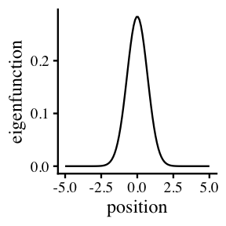

```r
set.seed(1024)
position <- matrix(seq(-5, 5, length = 100))
true_eigen_fn <- exp(-position^2) / norm(exp(-position^2), "F")

plot_df <- data.frame(position = position, eigenfunction = true_eigen_fn)

ggplot(plot_df, aes(position, eigenfunction)) +
  geom_line() +
  base_theme
```

## Case I: Higher signal of the true eigenfunction

#### Generate realizations

We want to generate 100 random sample based on - The spatial signal for the true spatial pattern is distributed normally with $\sigma=20$ - The noise follows the standard normal distribution.

```r
realizations <- rnorm(n = 100, sd = 20) %*% t(true_eigen_fn) + matrix(rnorm(n = 100 * 100), 100, 100)
```

#### Animate realizations

We can see simulated central realizations change in a wide range more frequently than the others.

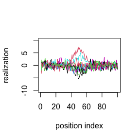

```r
subset_idx <- seq(1, 100, length.out = 9)
matplot(
  t(realizations[subset_idx, ]), type = "l", lty = 1,
  ylim = c(-10, 10),
  xlab = "position index", ylab = "realization"
)
```

#### Apply `SpatPCA::spatpca`

```r
cv <- spatpca(x = position, Y = realizations)
eigen_est <- cv$eigenfn
```

#### Compare **SpatPCA** with PCA

There are two comparison remarks 1. Two estimates are similar to the true eigenfunctions 2. **SpatPCA** can perform better at the both ends.

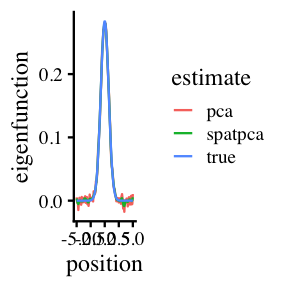

```r
plot_df <- data.frame(
  position = position,
  true = true_eigen_fn,
  spatpca = eigen_est[, 1],
  pca = svd(realizations)$v[, 1]
)

plot_df_long <- data.frame(
  position = rep(plot_df$position, 3),
  estimate = rep(c("true", "spatpca", "pca"), each = nrow(plot_df)),
  eigenfunction = c(plot_df$true, plot_df$spatpca, plot_df$pca)
)

ggplot(plot_df_long, aes(x = position, y = eigenfunction, color = estimate)) +
  geom_line() +
  base_theme
```

## Case II: Lower signal of the true eigenfunction

### Generate realizations with $\sigma=3$

```r
realizations <- rnorm(n = 100, sd = 3) %*% t(true_eigen_fn) + matrix(rnorm(n = 100 * 100), 100, 100)
```

### Animate realizations

It is hard to see a crystal clear spatial pattern via the simulated sample shown below.

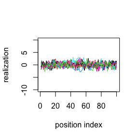

```r
subset_idx <- seq(1, 100, length.out = 9)
matplot(
  t(realizations[subset_idx, ]), type = "l", lty = 1,
  ylim = c(-10, 10),
  xlab = "position index", ylab = "realization"
)
```

### Compare resultant patterns

The following panel indicates that **SpatPCA** outperforms to PCA visually when the signal-to-noise ratio is quite lower.

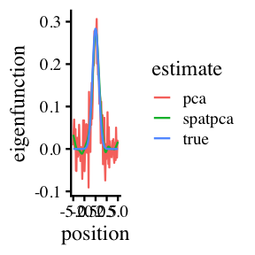

```r
cv <- spatpca(x = position, Y = realizations)
eigen_est <- cv$eigenfn

plot_df <- data.frame(
  position = position,
  true = true_eigen_fn,
  spatpca = eigen_est[, 1],
  pca = svd(realizations)$v[, 1]
)

plot_df_long <- data.frame(
  position = rep(plot_df$position, 3),
  estimate = rep(c("true", "spatpca", "pca"), each = nrow(plot_df)),
  eigenfunction = c(plot_df$true, plot_df$spatpca, plot_df$pca)
)

ggplot(plot_df_long, aes(x = position, y = eigenfunction, color = estimate)) +
  geom_line() +
  base_theme
```